```python
import numpy as np
import seaborn as sns
import pandas as pd
import matplotlib.pyplot as plt
%matplotlib inline
from plotly.offline import download_plotlyjs, init_notebook_mode, plot, iplot
import cufflinks as cf
init_notebook_mode(connected=True)
cf.go_offline()
```

# Reading and Analysing the Data

```python
house_data=pd.read_csv('kc_house_data.csv')
```

```python
house_data.head()
```

|  | id | date | price | bedrooms | bathrooms | sqft_living | sqft_lot | floors | waterfront | view | ... | grade | sqft_above | sqft_basement | yr_built | yr_renovated | zipcode | lat | long | sqft_living15 | sqft_lot15 |
| --- | --- | --- | --- | --- | --- | --- | --- | --- | --- | --- | --- | --- | --- | --- | --- | --- | --- | --- | --- | --- | --- |
| 0 | 7129300520 | 20141013T000000 | 221900.0 | 3 | 1.00 | 1180 | 5650 | 1.0 | 0 | 0 | ... | 7 | 1180 | 0 | 1955 | 0 | 98178 | 47.5112 | -122.257 | 1340 | 5650 |
| 1 | 6414100192 | 20141209T000000 | 538000.0 | 3 | 2.25 | 2570 | 7242 | 2.0 | 0 | 0 | ... | 7 | 2170 | 400 | 1951 | 1991 | 98125 | 47.7210 | -122.319 | 1690 | 7639 |
| 2 | 5631500400 | 20150225T000000 | 180000.0 | 2 | 1.00 | 770 | 10000 | 1.0 | 0 | 0 | ... | 6 | 770 | 0 | 1933 | 0 | 98028 | 47.7379 | -122.233 | 2720 | 8062 |
| 3 | 2487200875 | 20141209T000000 | 604000.0 | 4 | 3.00 | 1960 | 5000 | 1.0 | 0 | 0 | ... | 7 | 1050 | 910 | 1965 | 0 | 98136 | 47.5208 | -122.393 | 1360 | 5000 |
| 4 | 1954400510 | 20150218T000000 | 510000.0 | 3 | 2.00 | 1680 | 8080 | 1.0 | 0 | 0 | ... | 8 | 1680 | 0 | 1987 | 0 | 98074 | 47.6168 | -122.045 | 1800 | 7503 |

5 rows × 21 columns

**Removing unecessary features**

```python
house_data=house_data.drop(['waterfront','view','id'],axis=1)
```

```python
house_data.head()
```

|  | date | price | bedrooms | bathrooms | sqft_living | sqft_lot | floors | condition | grade | sqft_above | sqft_basement | yr_built | yr_renovated | zipcode | lat | long | sqft_living15 | sqft_lot15 |
| --- | --- | --- | --- | --- | --- | --- | --- | --- | --- | --- | --- | --- | --- | --- | --- | --- | --- | --- |
| 0 | 20141013T000000 | 221900.0 | 3 | 1.00 | 1180 | 5650 | 1.0 | 3 | 7 | 1180 | 0 | 1955 | 0 | 98178 | 47.5112 | -122.257 | 1340 | 5650 |
| 1 | 20141209T000000 | 538000.0 | 3 | 2.25 | 2570 | 7242 | 2.0 | 3 | 7 | 2170 | 400 | 1951 | 1991 | 98125 | 47.7210 | -122.319 | 1690 | 7639 |
| 2 | 20150225T000000 | 180000.0 | 2 | 1.00 | 770 | 10000 | 1.0 | 3 | 6 | 770 | 0 | 1933 | 0 | 98028 | 47.7379 | -122.233 | 2720 | 8062 |
| 3 | 20141209T000000 | 604000.0 | 4 | 3.00 | 1960 | 5000 | 1.0 | 5 | 7 | 1050 | 910 | 1965 | 0 | 98136 | 47.5208 | -122.393 | 1360 | 5000 |
| 4 | 20150218T000000 | 510000.0 | 3 | 2.00 | 1680 | 8080 | 1.0 | 3 | 8 | 1680 | 0 | 1987 | 0 | 98074 | 47.6168 | -122.045 | 1800 | 7503 |

```python
house_data.info()
```

```
<class 'pandas.core.frame.DataFrame'>
RangeIndex: 21613 entries, 0 to 21612
Data columns (total 18 columns):
date             21613 non-null object
price            21613 non-null float64
bedrooms         21613 non-null int64
bathrooms        21613 non-null float64
sqft_living      21613 non-null int64
sqft_lot         21613 non-null int64
floors           21613 non-null float64
condition        21613 non-null int64
grade            21613 non-null int64
sqft_above       21613 non-null int64
sqft_basement    21613 non-null int64
yr_built         21613 non-null int64
yr_renovated     21613 non-null int64
zipcode          21613 non-null int64
lat              21613 non-null float64
long             21613 non-null float64
sqft_living15    21613 non-null int64
sqft_lot15       21613 non-null int64
dtypes: float64(5), int64(12), object(1)
memory usage: 2.9+ MB
```

# Exploratory Data Analysis - Visualizations

*1) HEATMAP FOR CORRELATION ANALYSIS*

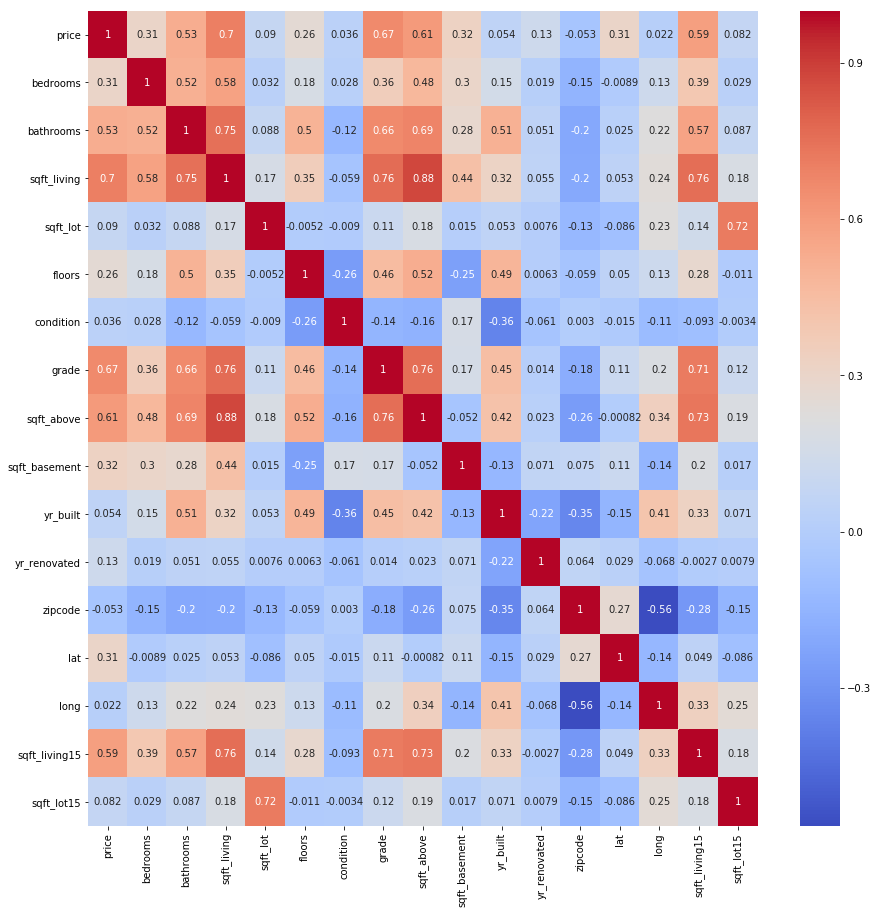

```python
plt.figure(figsize=(15,15))
sns.heatmap(house_data.corr(),annot=True,cmap='coolwarm')
plt.savefig('heatmap.png')
```

*2) JOINTPLOT BETWEEN AREA IN SQUARE FEET OF THE HOUSE AND PRICE*

```
C:\Users\Shivani Mangal\AppData\Local\Programs\Python\Python36-32\lib\site-packages\matplotlib\axes\_axes.py:6462: UserWarning:

The 'normed' kwarg is deprecated, and has been replaced by the 'density' kwarg.
```

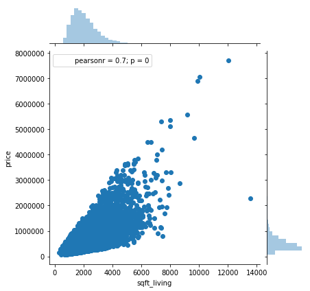

```python
sns.jointplot(x='sqft_living',y='price',data=house_data)
```

*2) JOINTPLOT BETWEEN AREA IN SQUARE FEET OF THE FLOORS ABOVE BASEMENT AND PRICE*

```
C:\Users\Shivani Mangal\AppData\Local\Programs\Python\Python36-32\lib\site-packages\matplotlib\axes\_axes.py:6462: UserWarning:

The 'normed' kwarg is deprecated, and has been replaced by the 'density' kwarg.
```

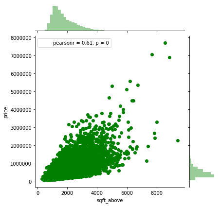

```python
sns.jointplot(x='sqft_above',y='price',data=house_data,color='green')
```

*3) JOINTPLOT BETWEEN AREA IN SQUARE FEET OF THE BASEMENT VERSUS PRICE*

```
C:\Users\Shivani Mangal\AppData\Local\Programs\Python\Python36-32\lib\site-packages\matplotlib\axes\_axes.py:6462: UserWarning:

The 'normed' kwarg is deprecated, and has been replaced by the 'density' kwarg.
```

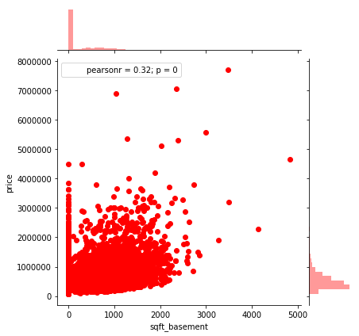

```python
sns.jointplot(x='sqft_basement',y='price',data=house_data,color='red')
```

*4) HISTOGRAM TO ANALYSE THE NUMBER OF HOUSES BUILT OVER THE YEARS*

```python
house_data['yr_built'].iplot(kind='hist')
```

[interactive chart not shown]

*5) BARPLOT BETWEEN NUMBER OF BEDROOMS AND PRICES*

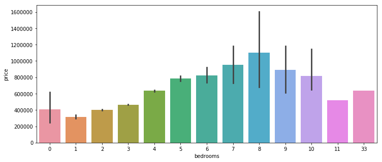

```python
plt.figure(figsize=(12,5))
sns.barplot(x='bedrooms',y='price',data=house_data)
```

*6) COUNTPLOT OF NUMBER OF OF BEDROOMS*

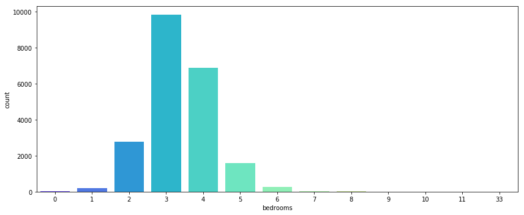

```python
plt.figure(figsize=(12,5))
sns.countplot(data=house_data,x='bedrooms',palette='rainbow')
plt.tight_layout()
```

*7) LINEAR MODEL PLOT BETWEEN NUMBER OF BATHROOMS AND SQUARE FEET OF AREA ABOVE BASEMENT, BASED ON THE GRADE OF THE HOUSE*

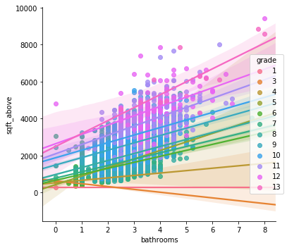

```python
plt.figure(figsize=(20,5))
sns.lmplot(x='bathrooms',y='sqft_above',data=house_data,hue='grade')
plt.tight_layout()
```

*7) LINEAR MODEL PLOT BETWEEN AREA OF THE HOUSE IN SQUARE FEET VERSUS PRICE, BASED ON THE CONDITION OF THE HOUSE*

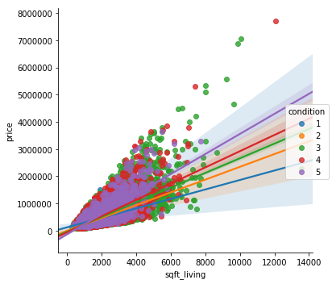

```python
plt.figure(figsize=(20,5))
sns.lmplot(x='sqft_living',y='price',data=house_data,hue='condition')
plt.tight_layout()
```

*8) BARPLOT OF ZIPCODE VERSUS PRICE*

```python
house_data.iplot(kind='bar',x='zipcode',y='price')
```

[interactive chart not shown]

*9) BARPLOT OF CONDITION VERSUS PRICE*

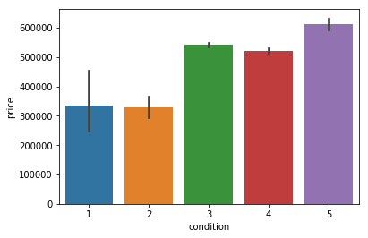

```python
sns.barplot(x='condition',y='price',data=house_data)
```

```
C:\Users\Shivani Mangal\AppData\Local\Programs\Python\Python36-32\lib\site-packages\matplotlib\axes\_axes.py:6462: UserWarning:

The 'normed' kwarg is deprecated, and has been replaced by the 'density' kwarg.
```

```
Text(0.5,1,'NORMAL DISTRIBUTION OF PRICES')
```

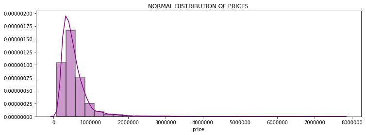

```python
plt.figure(figsize=(12,4))
sns.distplot(house_data['price'],bins=30,color='purple',hist_kws=dict(edgecolor="k", linewidth=2))
plt.title("NORMAL DISTRIBUTION OF PRICES")
```

# SUPERVISED LEARNING ALGORITHM - REGRESSION

*1) LINEAR REGRESSION*

```python
house_data.columns
```

```
Index(['date', 'price', 'bedrooms', 'bathrooms', 'sqft_living', 'sqft_lot',
       'floors', 'condition', 'grade', 'sqft_above', 'sqft_basement',
       'yr_built', 'yr_renovated', 'zipcode', 'lat', 'long', 'sqft_living15',
       'sqft_lot15'],
      dtype='object')
```

```python
X=house_data[['bedrooms', 'bathrooms', 'sqft_living',
       'sqft_lot', 'floors', 'condition', 'grade', 'sqft_above',
       'sqft_basement', 'yr_built','yr_renovated', 'zipcode', 'lat', 'long',
       'sqft_living15', 'sqft_lot15']]
```

```python
y=house_data['price']
```

```python
from sklearn.model_selection import train_test_split
```

```python
Xtrain,Xtest,ytrain,ytest=train_test_split(X,y,test_size=0.3,random_state=42)
```

```python
from sklearn.linear_model import LinearRegression
```

```python
lm = LinearRegression()
```

```python
lm.fit(Xtrain,ytrain)
```

```
LinearRegression(copy_X=True, fit_intercept=True, n_jobs=1, normalize=False)
```

```python
lm.coef_
```

```
array([-4.49601188e+04,  4.32862211e+04,  1.23363698e+02,  1.18535844e-01,
        1.00455536e+04,  2.60064337e+04,  9.92106398e+04,  6.63381258e+01,
        5.70255711e+01, -2.83650745e+03,  3.55698956e+01, -4.66609708e+02,
        5.45229838e+05, -2.38835137e+05,  3.53184008e+01, -2.63855820e-01])
```

```python
y_predicted=lm.predict(Xtest)
```

*NUMPY ARRAY OF PREDICTED PRICES*

```python
y_predicted
```

```
array([ 472495.99866127,  781806.23307372, 1177540.22298583, ...,
        367055.26749516,  855622.32641651,  571900.45539061])
```

*PERFORMANCE EVALUATION USING MEAN AVERAGE ERROR, MEAN SQUARE ERROR AND ROOT MEAN SQUARE ERROR*

```python
from sklearn import metrics
print("MAE:", metrics.mean_absolute_error(ytest,y_predicted))
print("MSE:", metrics.mean_squared_error(ytest,y_predicted))
print("RMSE:", np.sqrt(metrics.mean_squared_error(ytest,y_predicted)))
print(metrics.explained_variance_score(ytest,y_predicted))
```

```
MAE: 133938.38792114292
MSE: 49630460048.71565
RMSE: 222778.94884552187
0.65624585899162
```

*NORMAL DISTRIBUTION OF ERROR (TEST PRICE- PREDICTED PRICE)*

```
C:\Users\Shivani Mangal\AppData\Local\Programs\Python\Python36-32\lib\site-packages\matplotlib\axes\_axes.py:6462: UserWarning:

The 'normed' kwarg is deprecated, and has been replaced by the 'density' kwarg.
```

```
Text(0.5,1,'NORMAL DISTRIBUTION OF ERROR (TEST PRICE- PREDICTED PRICE)')
```

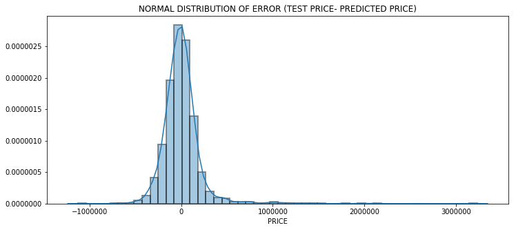

```python
plt.figure(figsize=(12,5))
sns.distplot((ytest-y_predicted),bins=50,hist_kws=dict(edgecolor="k", linewidth=2));
plt.xlabel("PRICE")
plt.title("NORMAL DISTRIBUTION OF ERROR (TEST PRICE- PREDICTED PRICE)")
```

*SCATTER PLOT TO COMPARE THE RELATIONSHIP BETWEEN TEST DATA AND PREDICTED DATA*

```
Text(0.5,1,'SCATTER PLOT TO COMPARE THE RELATIONSHIP BETWEEN TEST DATA AND PREDICTED DATA')
```

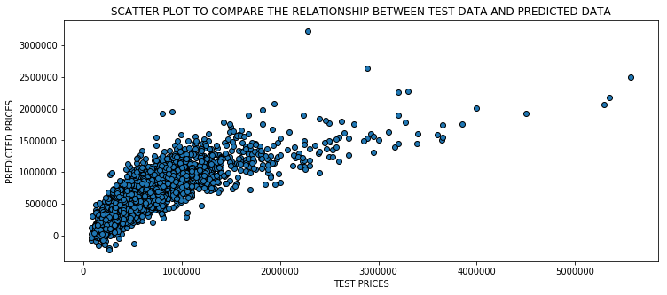

```python
plt.figure(figsize=(12,5))
plt.scatter(x=ytest,y=y_predicted,data=house_data,edgecolors='black')
#sns.lmplot(ytest,y_predicted,house_data)
plt.xlabel("TEST PRICES")
plt.ylabel("PREDICTED PRICES")
plt.title("SCATTER PLOT TO COMPARE THE RELATIONSHIP BETWEEN TEST DATA AND PREDICTED DATA")
```

*LINEAR REGRESSION CURVE*

```
Text(0,0.5,'Predicted Prices')
```

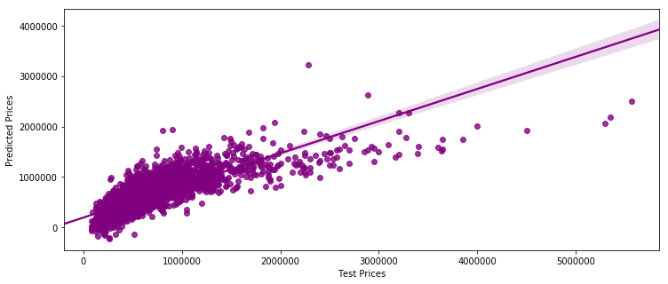

```python
plt.figure(figsize=(12,5))
sns.regplot(ytest,y_predicted,house_data,color='purple')
plt.xlabel("Test Prices")
plt.ylabel("Predicted Prices")
```

# UNSUPERVISED LEARNING

*2) K-MEANS CLUSTERING*

```python
from sklearn.cluster import KMeans
```

```python
km = KMeans(n_clusters=2)
```

```python
km.fit(house_data.drop(['date', 'price',],axis=1))
```

```
KMeans(algorithm='auto', copy_x=True, init='k-means++', max_iter=300,
    n_clusters=2, n_init=10, n_jobs=1, precompute_distances='auto',
    random_state=None, tol=0.0001, verbose=0)
```

*GENERATED CLUSTER CENTERS AND LABELS*

```python
km.cluster_centers_
```

[output not shown]

```python
km.labels_
```

```
array([1, 1, 1, ..., 0, 0, 0])
```

# BASIC FEATURE ENGINEERING

*BASIC FEATURE ENGINEERING TO CREATE A LABELLED COLUMN CALLED CLUSTERS FOR FURTHER SUPERVISED LEARNING*

```python
house_data['price'].mean()
```

```
540088.1417665294
```

```python
def cluster_vals (cost):
    if cost > 540088.1417665294:
        return 1
    else:
        return 0
house_data['Cluster']=house_data['price'].apply(cluster_vals)
```

```python
house_data.head(2)
```

|  | date | price | bedrooms | bathrooms | sqft_living | sqft_lot | floors | condition | grade | sqft_above | sqft_basement | yr_built | yr_renovated | zipcode | lat | long | sqft_living15 | sqft_lot15 | Cluster |
| --- | --- | --- | --- | --- | --- | --- | --- | --- | --- | --- | --- | --- | --- | --- | --- | --- | --- | --- | --- |
| 0 | 20141013T000000 | 221900.0 | 3 | 1.00 | 1180 | 5650 | 1.0 | 3 | 7 | 1180 | 0 | 1955 | 0 | 98178 | 47.5112 | -122.257 | 1340 | 5650 | 0 |
| 1 | 20141209T000000 | 538000.0 | 3 | 2.25 | 2570 | 7242 | 2.0 | 3 | 7 | 2170 | 400 | 1951 | 1991 | 98125 | 47.7210 | -122.319 | 1690 | 7639 | 0 |

*HISTOGRAM OF AREA IN SQUARE FEET OF LIVING AREA BASED ON MEAN PRICE*

```
Text(0.5,0,'Square Feet of Living Area')
```

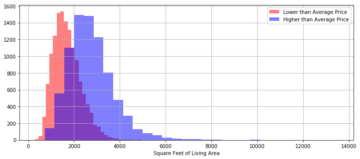

```python
plt.figure(figsize=(12,5))
house_data[house_data['Cluster']==0]['sqft_living'].hist(alpha=0.5,bins=30,label='Lower than Average Price',color='red')
house_data[house_data['Cluster']==1]['sqft_living'].hist(alpha=0.5,bins=30,label='Higher than Average Price',color='blue')
plt.legend()
plt.xlabel('Square Feet of Living Area')
```

*COMPARISON OF CLUSTER CLASSIFIER LABEL WITH GENERATED K-MEANS LABELS FOR PERFORMANCE ANALYSIS*

```python
from sklearn.metrics import confusion_matrix,classification_report
print("CONFUSION MATRIX:\n\n ",confusion_matrix(house_data['Cluster'],km.labels_))
print("\nCLASSIFICATION REPORT:\n\n",classification_report(house_data['Cluster'],km.labels_))
```

```
CONFUSION MATRIX:

  [[7840 5854]
 [4508 3411]]

CLASSIFICATION REPORT:

              precision    recall  f1-score   support

          0       0.63      0.57      0.60     13694
          1       0.37      0.43      0.40      7919

avg / total       0.54      0.52      0.53     21613
```

# FURTHER SUPERVISED LEARNING

*3) LOGISTIC REGRESSION - CLASSIFICATION*

```python
from sklearn.linear_model import LogisticRegression
```

```python
lr = LogisticRegression()
```

```python
y = house_data['Cluster']
```

```python
X_train, X_test, y_train, y_test = train_test_split(X,y,test_size=0.3,random_state=101)
```

```python
lr.fit(X_train,y_train)
```

```
LogisticRegression(C=1.0, class_weight=None, dual=False, fit_intercept=True,
          intercept_scaling=1, max_iter=100, multi_class='ovr', n_jobs=1,
          penalty='l2', random_state=None, solver='liblinear', tol=0.0001,
          verbose=0, warm_start=False)
```

```python
predictions = lr.predict(X_test)
```

```python
predictions
```

```
array([0, 0, 0, ..., 0, 0, 1], dtype=int64)
```

*PERFORMANCE ANALYSIS*

```python
print("\nCLASSIFICATION REPORT:\n\n",classification_report(y_test,predictions))
print("\nCONFUSION MATRIX: \n\n",confusion_matrix(y_test,predictions))
```

```
CLASSIFICATION REPORT:

              precision    recall  f1-score   support

          0       0.81      0.90      0.85      4094
          1       0.79      0.64      0.71      2390

avg / total       0.80      0.81      0.80      6484


CONFUSION MATRIX:

 [[3686  408]
 [ 850 1540]]
```

*4) DECISION TREE CLASSIFICATION*

```python
from sklearn.tree import DecisionTreeClassifier
```

```python
dtree = DecisionTreeClassifier()
```

```python
dtree.fit(X_train,y_train)
```

```
DecisionTreeClassifier(class_weight=None, criterion='gini', max_depth=None,
            max_features=None, max_leaf_nodes=None,
            min_impurity_decrease=0.0, min_impurity_split=None,
            min_samples_leaf=1, min_samples_split=2,
            min_weight_fraction_leaf=0.0, presort=False, random_state=None,
            splitter='best')
```

```python
preds = dtree.predict(X_test)
```

```python
preds
```

```
array([0, 0, 1, ..., 0, 0, 1], dtype=int64)
```

*PERFORMANCE ANALYSIS*

```python
print("\nCLASSIFICATION REPORT:\n\n",classification_report(y_test,preds))
print("\nCONFUSION MATRIX: \n\n",confusion_matrix(y_test,preds))
```

```
CLASSIFICATION REPORT:

              precision    recall  f1-score   support

          0       0.90      0.91      0.90      4094
          1       0.84      0.83      0.83      2390

avg / total       0.88      0.88      0.88      6484


CONFUSION MATRIX:

 [[3725  369]
 [ 414 1976]]
```

*5) RANDOM FOREST CLASSIFICATION*

```python
from sklearn.ensemble import RandomForestClassifier
```

```python
rfc = RandomForestClassifier(n_estimators=300)
```

```python
rfc.fit(X_train,y_train)
```

```
RandomForestClassifier(bootstrap=True, class_weight=None, criterion='gini',
            max_depth=None, max_features='auto', max_leaf_nodes=None,
            min_impurity_decrease=0.0, min_impurity_split=None,
            min_samples_leaf=1, min_samples_split=2,
            min_weight_fraction_leaf=0.0, n_estimators=300, n_jobs=1,
            oob_score=False, random_state=None, verbose=0,
            warm_start=False)
```

```python
preds = rfc.predict(X_test)
```

```python
preds
```

```
array([0, 0, 1, ..., 0, 0, 1], dtype=int64)
```

*PERFORMANCE ANALYSIS*

```python
print("\nCLASSIFICATION REPORT:\n\n",classification_report(y_test,preds))
print("\nCONFUSION MATRIX: \n\n",confusion_matrix(y_test,preds))
```

```
CLASSIFICATION REPORT:

              precision    recall  f1-score   support

          0       0.93      0.94      0.94      4094
          1       0.90      0.87      0.89      2390

avg / total       0.92      0.92      0.92      6484


CONFUSION MATRIX:

 [[3863  231]
 [ 301 2089]]
```